# Weakly Informative Examples

# Do beautiful parents have more daughters?

```r
library(rstan)

data_list <- list(
  n_attractive = 300,
  n_daughters_attractive = 170,
  n_nonattractive = 2700,
  n_daughters_nonattractive = 1310
)

dat_frm <- matrix(c(170,300,0.567, 1310,2700, 0.485), 2, 3, byrow = T)
rownames(dat_frm) <- c("Beautiful", "Average")
colnames(dat_frm) <- c("Daughters", "Total", "Proportion")

print(dat_frm)
```

```
##           Daughters Total Proportion
## Beautiful       170   300      0.567
## Average        1310  2700      0.485
```

## Model with uniform prior

$y_1\sim Binomial(300,p_1)$,$y_0 \sim Binomial(2700, p_0)$,

```r
stan_code_uniform<- "
data {
  int<lower=0> n_attractive;      // Total number of attractive parents
  int<lower=0> n_daughters_attractive;  // Number of attractive parents with daughters

  int<lower=0> n_nonattractive;      // Total number of non-attractive parents
  int<lower=0> n_daughters_nonattractive;  // Number of non-attractive parents with daughters
}

parameters {
  real<lower=0, upper=1> p_nonattractive;  // Proportion of non-attractive parents having daughters
  real<lower=-1, upper=1> p_attractive;      //
}

transformed parameters {
  real<lower=0, upper=1> difference =p_attractive- p_nonattractive;  // Calculate p_attractive from difference
}

model {
  // Uniform priors
  p_nonattractive ~ uniform(0, 1);
  p_attractive ~ uniform(0, 1);

  // Binomial likelihood
  n_daughters_attractive ~ binomial(n_attractive, p_attractive);
  n_daughters_nonattractive ~ binomial(n_nonattractive, p_nonattractive);
}


"

model2 <- stan_model(model_code=stan_code_uniform)
# Sample from the model
fit2 <- sampling(model2, data=data_list, chains=4, iter=2000, warmup=1000, cores=4, refresh=0)
print(fit2, digits=3)
```

```
## Inference for Stan model: anon_model.
## 4 chains, each with iter=2000; warmup=1000; thin=1;
## post-warmup draws per chain=1000, total post-warmup draws=4000.
##
##                      mean se_mean    sd      2.5%       25%       50%       75%
## p_nonattractive     0.485   0.000 0.010     0.466     0.479     0.485     0.492
## p_attractive        0.566   0.000 0.028     0.512     0.547     0.567     0.585
## difference          0.081   0.001 0.030     0.024     0.060     0.081     0.102
## lp__            -2079.064   0.022 0.976 -2081.618 -2079.476 -2078.773 -2078.365
##                     97.5% n_eff  Rhat
## p_nonattractive     0.504  3050 1.000
## p_attractive        0.622  3426 1.000
## difference          0.140  3346 1.000
## lp__            -2078.079  1915 1.001
##
## Samples were drawn using NUTS(diag_e) at Tue Nov  7 16:51:17 2023.
## For each parameter, n_eff is a crude measure of effective sample size,
## and Rhat is the potential scale reduction factor on split chains (at
## convergence, Rhat=1).
```

## What does non-informative prior mean here?

Distribution of sample mean for the beautiful parents group.

[figure not shown]

```r
n <- 300
reject_lb <- 0.49 - 1.96*sqrt(1/n*0.49*0.51)
reject_ub <- 0.49 + 1.96*sqrt(1/n*0.49*0.51)

# Parameters for the normal distribution


# Plot the density
par(mfrow=c(2,2))
mean_val <- 0.51
sd_val <- sqrt(1/n*mean_val*(1-mean_val))
curve(dnorm(x, mean=mean_val, sd=sd_val),
      from = 0.4,
      to = 0.7,
      ylab="Density", xlab="Value",
      main="True Mean = 0.51, likelihood = 2",
      lwd=2, col="blue")

grid()
#abline(v=0.49)
abline(v=0.51,col=2)
abline(v=170/300,col=3,lwd=2)

mean_val <- 0.54
sd_val <- sqrt(1/n*mean_val*(1-mean_val))
curve(dnorm(x, mean=mean_val, sd=sd_val),
      from = 0.4,
      to = 0.7,
      ylab="Density", xlab="Value",
      main="True Mean = 0.53, likelihood = 10",
      lwd=2, col="blue")

grid()
#abline(v=0.49)
abline(v=0.54,col=2)
abline(v=170/300,col=3,lwd=2)


mean_val <- 0.57
sd_val <- sqrt(1/n*mean_val*(1-mean_val))
curve(dnorm(x, mean=mean_val, sd=sd_val),
      from = 0.4,
      to = 0.7,
      ylab="Density", xlab="Value",
      main="True Mean = 0.57, likelihood = 14",
      lwd=2, col="blue")

grid()
#abline(v=0.49)
#abline(v=0.56,col=2)
abline(v=170/300,col=3,lwd=2)

mean_val <- 0.6
sd_val <- sqrt(1/n*mean_val*(1-mean_val))
curve(dnorm(x, mean=mean_val, sd=sd_val),
      from = 0.4,
      to = 0.7,
      ylab="Density", xlab="Value",
      main="True Mean = 0.6, likelihood = 8",
      lwd=2, col="blue")

grid()
#abline(v=0.49)
abline(v=0.6,col=2)
abline(v=170/300,col=3,lwd=2)
```

Uniform prior means that the posterior probability of each senario only depends on the likelihood.

## Model with weakly informative prior on difference

$y_1\sim Binomial(300,p_1)$,$y_0 \sim Binomial(2700, p_0)$, reparameterized to $p_0$ and $p_{diff} = p_1-p_0$

Assuming the difference p1-p0 is less than 1.5% with 95% probability. The intuition is that p0 is 0.485,and we don’t believe p1 is greater than 0.5

```r
stan_code_weakly_inform <- "
data {
  int<lower=0> n_attractive;      // Total number of attractive parents
  int<lower=0> n_daughters_attractive;  // Number of attractive parents with daughters

  int<lower=0> n_nonattractive;      // Total number of non-attractive parents
  int<lower=0> n_daughters_nonattractive;  // Number of non-attractive parents with daughters
}

parameters {
  real<lower=0, upper=1> p_nonattractive;  // Proportion of non-attractive parents having daughters
  real<lower=-1, upper=1> difference;      // p_attractive - p_nonattractive
}

transformed parameters {
  real<lower=0, upper=1> p_attractive = p_nonattractive + difference;  // Calculate p_attractive from difference
}

model {
  // Uniform priors
  p_nonattractive ~ uniform(0, 1);
  difference ~ normal(0, 0.007);

  // Binomial likelihood
  n_daughters_attractive ~ binomial(n_attractive, p_attractive);
  n_daughters_nonattractive ~ binomial(n_nonattractive, p_nonattractive);
}


"

model4 <- stan_model(model_code=stan_code_weakly_inform)


# Sample from the model
fit4 <- sampling(model4, data=data_list, chains=4, iter=2000, warmup=1000, cores=4, refresh=0)
print(fit4, digits=3)
```

```
## Inference for Stan model: anon_model.
## 4 chains, each with iter=2000; warmup=1000; thin=1;
## post-warmup draws per chain=1000, total post-warmup draws=4000.
##
##                      mean se_mean    sd      2.5%       25%       50%       75%
## p_nonattractive     0.493   0.000 0.009     0.475     0.487     0.493     0.499
## difference          0.004   0.000 0.007    -0.009    -0.001     0.004     0.008
## p_attractive        0.497   0.000 0.011     0.476     0.489     0.497     0.504
## lp__            -2082.058   0.022 0.991 -2084.602 -2082.416 -2081.769 -2081.367
##                     97.5% n_eff  Rhat
## p_nonattractive     0.511  2931 1.003
## difference          0.017  2971 1.000
## p_attractive        0.518  3012 1.002
## lp__            -2081.098  2074 1.001
##
## Samples were drawn using NUTS(diag_e) at Tue Nov  7 16:52:10 2023.
## For each parameter, n_eff is a crude measure of effective sample size,
## and Rhat is the potential scale reduction factor on split chains (at
## convergence, Rhat=1).
```

## Complete seperation problem in Logistic Regression

The complete separation problem arises in logistic regression when the outcome variable can be perfectly predicted by one or more predictors. This causes the maximum likelihood estimates for the coefficients to be infinite, which is problematic for interpretation and for making predictions.

### Sample Data

```r
set.seed(123)
x <- c(rep(0,50),rep(1,50))
y <- (x==0)*rbinom(50,1,0.5)+(x>0)*1
table(x,y)
```

```
##    y
## x    0  1
##   0 25 25
##   1  0 50
```

### Logistic Regression Model

Logistic Regression: $y\sim Bernoulli(p)$

$$log(\frac{p}{1-p})=\alpha +
\beta*x$$

$$p = \frac{e^{\alpha +
\beta*x}}{1+e^{\alpha + \beta*x}}$$
Reparameterization $\beta_0=\alpha , \beta_1 = \beta+\alpha$:

When $x=0$,

$$log(\frac{p}{1-p})=\beta_0 \Rightarrow
p=\frac{e^{\beta_0}}{1+e^{\beta_0}}$$
;

When $x=1$,
$$log(\frac{p}{1-p})=\beta_1 \Rightarrow
p=\frac{e^{\beta_1}}{1+e^{\beta_1}}$$

Likelihood:

$$L(\beta \mid Data ) =
p^{25}_{x=0}(1-p_{x=0})^{25}p^{50}_{x=1}$$
$$L(\beta\mid Data
)=\left(\frac{e^{\beta_0}}{1+e^{\beta_0}}\right)^{25}\left(\frac{1}{1+e^{\beta_0}}\right)^{25}\left(\frac{e^{\beta_1}}{1+e^{\beta_1}}\right)^{50}$$

To maximize the likelihood, $\beta_1$ has to go to infinity.

## Bayesian with flat prior and frequentist glm blow up

```r
# This will fail with traditional glm:
# glm.fit <- glm(y ~ x, family = binomial())
# Warning message:
# glm.fit: algorithm did not converge

# Using RStan:

library(rstan)

# Model specification
stan_model_flat <- "
data {
  int<lower=0> N;
  vector[N] x;
  int<lower=0,upper=1> y[N];
}
parameters {
  real alpha;
  real beta;
}
model {
  y ~ bernoulli_logit(alpha + beta * x);
}
"

# Compiling and fitting
fit_flat <- stan(model_code = stan_model_flat, data = list(N = length(y), x = x, y = y), refresh=0)
# Viewing results
print(fit_flat)
```

```
## Inference for Stan model: anon_model.
## 4 chains, each with iter=2000; warmup=1000; thin=1;
## post-warmup draws per chain=1000, total post-warmup draws=4000.
##
##                mean      se_mean           sd          2.5%           25%
## alpha  0.000000e+00 0.000000e+00 2.800000e-01 -5.600000e-01 -1.900000e-01
## beta   4.495109e+20 3.831512e+20 6.736152e+20  2.246027e+18  2.456982e+19
## lp__  -3.513000e+01 2.000000e-02 6.700000e-01 -3.696000e+01 -3.529000e+01
##                 50%           75%         97.5% n_eff Rhat
## alpha  0.000000e+00  1.900000e-01  5.300000e-01  3767 1.00
## beta   1.079659e+20  5.639275e+20  2.481296e+21     3 3.66
## lp__  -3.488000e+01 -3.471000e+01 -3.466000e+01  1942 1.00
##
## Samples were drawn using NUTS(diag_e) at Tue Nov  7 16:53:19 2023.
## For each parameter, n_eff is a crude measure of effective sample size,
## and Rhat is the potential scale reduction factor on split chains (at
## convergence, Rhat=1).
```

```r
summary(glm(y~x, family=binomial))
```

```
##
## Call:
## glm(formula = y ~ x, family = binomial)
##
## Coefficients:
##               Estimate Std. Error z value Pr(>|z|)
## (Intercept) -4.119e-16  2.828e-01   0.000     1.00
## x            1.957e+01  1.521e+03   0.013     0.99
##
## (Dispersion parameter for binomial family taken to be 1)
##
##     Null deviance: 112.467  on 99  degrees of freedom
## Residual deviance:  69.315  on 98  degrees of freedom
## AIC: 73.315
##
## Number of Fisher Scoring iterations: 18
```

## Let’s put some information in the model

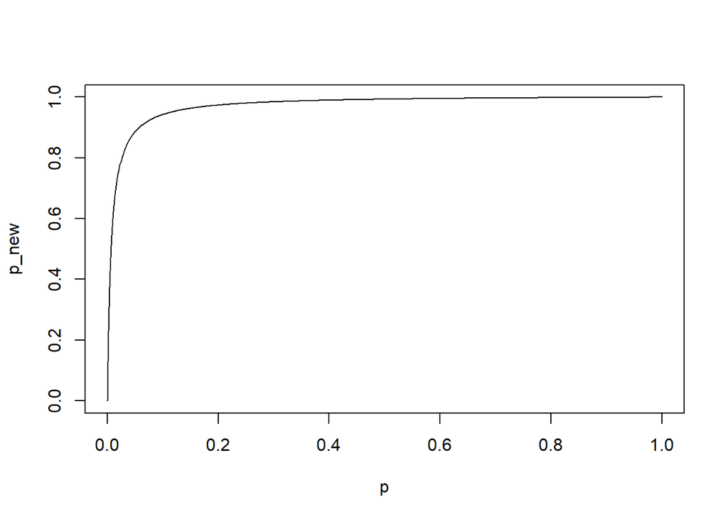

```r
logistic_prob <- function(coef,p){
  1/(1+exp(-5)*(1-p)/p)
}

p <- seq(0,1,length.out=1000)
p_new <- logistic_prob(5, p)
plot(p,p_new, type="line")
```

[figure not shown]

```r
# Load necessary libraries
library(ggplot2)
# Parameters for the t-distribution
df <- 7
scale <- 2.5

# Values for plotting
x_value <- seq(-10*scale, 10*scale, length.out = 1000)
y_value <- dt(x_value/scale, df=df)

# Quantiles
q10 <- 2.5*qt(0.10, df=df) * scale
q90 <- 2.5*qt(0.90, df=df) * scale

# Plot
plot(x_value, y_value, type="l", lwd=2, ylab="Density", xlab="Value",
     main="Density of scaled t-distribution")

# Add vertical lines for the quantiles
abline(v=q10, col="red", lty=2)
abline(v=q90, col="red", lty=2)

# Add text labels for the quantiles
text(q10, 0.05, "10%", pos=4, col="red")
text(q90, 0.05, "90%", pos=2, col="red")
```

## Logistic Regression (t distribution)

```r
# Model specification
stan_model_t7_2.5 <- "
data {
  int<lower=0> N;
  vector[N] x;
  int<lower=0,upper=1> y[N];
}
parameters {
  real alpha;
  real beta;
}
model {
  y ~ bernoulli_logit(alpha + beta * x);
  alpha ~ student_t(7, 0, 2.5);
  beta ~ student_t(7, 0, 2.5);
}
"

# Compiling and fitting
fit_t7_2.5 <- stan(model_code = stan_model_t7_2.5, data = list(N = length(y), x = x, y = y), refresh=0)

# Viewing results
print(fit_t7_2.5)
```

```
## Inference for Stan model: anon_model.
## 4 chains, each with iter=2000; warmup=1000; thin=1;
## post-warmup draws per chain=1000, total post-warmup draws=4000.
##
##         mean se_mean   sd   2.5%    25%    50%    75%  97.5% n_eff Rhat
## alpha   0.05    0.01 0.29  -0.53  -0.14   0.05   0.24   0.59  1971    1
## beta    5.45    0.06 1.96   2.77   4.12   5.04   6.35  10.19  1137    1
## lp__  -37.85    0.03 1.09 -40.73 -38.32 -37.51 -37.03 -36.74  1130    1
##
## Samples were drawn using NUTS(diag_e) at Tue Nov  7 16:53:56 2023.
## For each parameter, n_eff is a crude measure of effective sample size,
## and Rhat is the potential scale reduction factor on split chains (at
## convergence, Rhat=1).
```

```r
# Model specification
stan_model_norm2.5 <- "
data {
  int<lower=0> N;
  vector[N] x;
  int<lower=0,upper=1> y[N];
}
parameters {
  real alpha;
  real beta;
}
model {
  y ~ bernoulli_logit(alpha + beta * x);
  alpha ~ normal(0,2.5);
  beta ~ normal(0,2.5);
}
"

# Compiling and fitting
fit_norm2.5 <- stan(model_code = stan_model_norm2.5, data = list(N = length(y), x = x, y = y), refresh=0)

# Viewing results
print(fit_norm2.5)
```

```
## Inference for Stan model: anon_model.
## 4 chains, each with iter=2000; warmup=1000; thin=1;
## post-warmup draws per chain=1000, total post-warmup draws=4000.
##
##         mean se_mean   sd   2.5%    25%    50%    75%  97.5% n_eff Rhat
## alpha   0.05    0.01 0.27  -0.49  -0.14   0.06   0.24   0.58  2328    1
## beta    4.72    0.03 1.29   2.67   3.80   4.56   5.46   7.84  1931    1
## lp__  -37.83    0.03 1.05 -40.63 -38.19 -37.54 -37.09 -36.82  1471    1
##
## Samples were drawn using NUTS(diag_e) at Tue Nov  7 16:54:32 2023.
## For each parameter, n_eff is a crude measure of effective sample size,
## and Rhat is the potential scale reduction factor on split chains (at
## convergence, Rhat=1).
```

## Conclusion

1. Without any prior information, the data might not be able to speak for itself.
2. We use less information than we actually have, but enough to give a stable answer.